# Assignment 1

Gus Lipkin ~ glipkin6737@floridapoly.edu

# Problem 8

> This exercise relates to the `College` data set, which can be found in the file `College.csv` on the book website. It contains a number of variables for 777 different universities and colleges in the US. The variables are

> [ommitted for simplicity]

> Before reading the data into `R, it can be viewed in Excel or a text editor.

## 8a

> Use the `read.csv()` function to read the data into R. Call the loaded data `college.` Make sure that you have the directory set to the correct location for the data.

```r
college <- read.csv("College.csv")
```

# 8b

> Look at the data using the `View()` function. You should notice that the first column is just the name of each university. We don’t really want R to treat this as data. However, it may be handy to have these names for later. Try the following commands:

> `rownames(college) <- college[, 1]`

> `View(college)`

> You should see that there is now a `row.names` column with the name of each university recorded. This means that R has given each row a name corresponding to the appropriate university. R will not try to perform calculations on the row names. However, we still need to eliminate the first column in the data where the names are stored. Try

> `college <- college[, -1]`

> `View(college)`

> Now you should see that the first data column is `Private.` Note that another column labeled `row.names` now appears before the `Private` column. However, this is not a data column but rather the name that R is giving to each row.

```r
# Commenting this out because it doesn't work with html notebooks
# View(college)
head(college)
```

|  | X | Private | Apps | Accept | Enroll | Top10perc | Top25perc | F.Undergrad | P.Undergrad | Outstate | Room.Board | Books | Personal | PhD | Terminal | S.F.Ratio | perc.alumni | Expend | Grad.Rate |
| --- | --- | --- | --- | --- | --- | --- | --- | --- | --- | --- | --- | --- | --- | --- | --- | --- | --- | --- | --- |
| 1 | Abilene Christian University | Yes | 1660 | 1232 | 721 | 23 | 52 | 2885 | 537 | 7440 | 3300 | 450 | 2200 | 70 | 78 | 18.1 | 12 | 7041 | 60 |
| 2 | Adelphi University | Yes | 2186 | 1924 | 512 | 16 | 29 | 2683 | 1227 | 12280 | 6450 | 750 | 1500 | 29 | 30 | 12.2 | 16 | 10527 | 56 |
| 3 | Adrian College | Yes | 1428 | 1097 | 336 | 22 | 50 | 1036 | 99 | 11250 | 3750 | 400 | 1165 | 53 | 66 | 12.9 | 30 | 8735 | 54 |
| 4 | Agnes Scott College | Yes | 417 | 349 | 137 | 60 | 89 | 510 | 63 | 12960 | 5450 | 450 | 875 | 92 | 97 | 7.7 | 37 | 19016 | 59 |
| 5 | Alaska Pacific University | Yes | 193 | 146 | 55 | 16 | 44 | 249 | 869 | 7560 | 4120 | 800 | 1500 | 76 | 72 | 11.9 | 2 | 10922 | 15 |
| 6 | Albertson College | Yes | 587 | 479 | 158 | 38 | 62 | 678 | 41 | 13500 | 3335 | 500 | 675 | 67 | 73 | 9.4 | 11 | 9727 | 55 |

```r
# Using row names is outdated...
rownames(college) <- college[, 1]
# View(college)
head(college)
```

|  | X | Private | Apps | Accept | Enroll | Top10perc | Top25perc | F.Undergrad | P.Undergrad | Outstate | Room.Board | Books | Personal | PhD | Terminal | S.F.Ratio | perc.alumni | Expend | Grad.Rate |
| --- | --- | --- | --- | --- | --- | --- | --- | --- | --- | --- | --- | --- | --- | --- | --- | --- | --- | --- | --- |
| Abilene Christian University | Abilene Christian University | Yes | 1660 | 1232 | 721 | 23 | 52 | 2885 | 537 | 7440 | 3300 | 450 | 2200 | 70 | 78 | 18.1 | 12 | 7041 | 60 |
| Adelphi University | Adelphi University | Yes | 2186 | 1924 | 512 | 16 | 29 | 2683 | 1227 | 12280 | 6450 | 750 | 1500 | 29 | 30 | 12.2 | 16 | 10527 | 56 |
| Adrian College | Adrian College | Yes | 1428 | 1097 | 336 | 22 | 50 | 1036 | 99 | 11250 | 3750 | 400 | 1165 | 53 | 66 | 12.9 | 30 | 8735 | 54 |
| Agnes Scott College | Agnes Scott College | Yes | 417 | 349 | 137 | 60 | 89 | 510 | 63 | 12960 | 5450 | 450 | 875 | 92 | 97 | 7.7 | 37 | 19016 | 59 |
| Alaska Pacific University | Alaska Pacific University | Yes | 193 | 146 | 55 | 16 | 44 | 249 | 869 | 7560 | 4120 | 800 | 1500 | 76 | 72 | 11.9 | 2 | 10922 | 15 |
| Albertson College | Albertson College | Yes | 587 | 479 | 158 | 38 | 62 | 678 | 41 | 13500 | 3335 | 500 | 675 | 67 | 73 | 9.4 | 11 | 9727 | 55 |

```r
college <- college[, -1]
# View(college)
head(college)
```

|  | Private | Apps | Accept | Enroll | Top10perc | Top25perc | F.Undergrad | P.Undergrad | Outstate | Room.Board | Books | Personal | PhD | Terminal | S.F.Ratio | perc.alumni | Expend | Grad.Rate |
| --- | --- | --- | --- | --- | --- | --- | --- | --- | --- | --- | --- | --- | --- | --- | --- | --- | --- | --- |
| Abilene Christian University | Yes | 1660 | 1232 | 721 | 23 | 52 | 2885 | 537 | 7440 | 3300 | 450 | 2200 | 70 | 78 | 18.1 | 12 | 7041 | 60 |
| Adelphi University | Yes | 2186 | 1924 | 512 | 16 | 29 | 2683 | 1227 | 12280 | 6450 | 750 | 1500 | 29 | 30 | 12.2 | 16 | 10527 | 56 |
| Adrian College | Yes | 1428 | 1097 | 336 | 22 | 50 | 1036 | 99 | 11250 | 3750 | 400 | 1165 | 53 | 66 | 12.9 | 30 | 8735 | 54 |
| Agnes Scott College | Yes | 417 | 349 | 137 | 60 | 89 | 510 | 63 | 12960 | 5450 | 450 | 875 | 92 | 97 | 7.7 | 37 | 19016 | 59 |
| Alaska Pacific University | Yes | 193 | 146 | 55 | 16 | 44 | 249 | 869 | 7560 | 4120 | 800 | 1500 | 76 | 72 | 11.9 | 2 | 10922 | 15 |
| Albertson College | Yes | 587 | 479 | 158 | 38 | 62 | 678 | 41 | 13500 | 3335 | 500 | 675 | 67 | 73 | 9.4 | 11 | 9727 | 55 |

## 8c

### 8c i

> Use the `summary()` function to produce a numerical summary of the variables in the data set.

```r
summary(college)
```

```
   Private               Apps           Accept          Enroll       Top10perc       Top25perc      F.Undergrad
 Length:777         Min.   :   81   Min.   :   72   Min.   :  35   Min.   : 1.00   Min.   :  9.0   Min.   :  139
 Class :character   1st Qu.:  776   1st Qu.:  604   1st Qu.: 242   1st Qu.:15.00   1st Qu.: 41.0   1st Qu.:  992
 Mode  :character   Median : 1558   Median : 1110   Median : 434   Median :23.00   Median : 54.0   Median : 1707
                    Mean   : 3002   Mean   : 2019   Mean   : 780   Mean   :27.56   Mean   : 55.8   Mean   : 3700
                    3rd Qu.: 3624   3rd Qu.: 2424   3rd Qu.: 902   3rd Qu.:35.00   3rd Qu.: 69.0   3rd Qu.: 4005
                    Max.   :48094   Max.   :26330   Max.   :6392   Max.   :96.00   Max.   :100.0   Max.   :31643
  P.Undergrad         Outstate       Room.Board       Books           Personal         PhD            Terminal
 Min.   :    1.0   Min.   : 2340   Min.   :1780   Min.   :  96.0   Min.   : 250   Min.   :  8.00   Min.   : 24.0
 1st Qu.:   95.0   1st Qu.: 7320   1st Qu.:3597   1st Qu.: 470.0   1st Qu.: 850   1st Qu.: 62.00   1st Qu.: 71.0
 Median :  353.0   Median : 9990   Median :4200   Median : 500.0   Median :1200   Median : 75.00   Median : 82.0
 Mean   :  855.3   Mean   :10441   Mean   :4358   Mean   : 549.4   Mean   :1341   Mean   : 72.66   Mean   : 79.7
 3rd Qu.:  967.0   3rd Qu.:12925   3rd Qu.:5050   3rd Qu.: 600.0   3rd Qu.:1700   3rd Qu.: 85.00   3rd Qu.: 92.0
 Max.   :21836.0   Max.   :21700   Max.   :8124   Max.   :2340.0   Max.   :6800   Max.   :103.00   Max.   :100.0
   S.F.Ratio      perc.alumni        Expend        Grad.Rate
 Min.   : 2.50   Min.   : 0.00   Min.   : 3186   Min.   : 10.00
 1st Qu.:11.50   1st Qu.:13.00   1st Qu.: 6751   1st Qu.: 53.00
 Median :13.60   Median :21.00   Median : 8377   Median : 65.00
 Mean   :14.09   Mean   :22.74   Mean   : 9660   Mean   : 65.46
 3rd Qu.:16.50   3rd Qu.:31.00   3rd Qu.:10830   3rd Qu.: 78.00
 Max.   :39.80   Max.   :64.00   Max.   :56233   Max.   :118.00
```

### 8c ii

> Use the `pairs()` function to produce a scatterplot matrix of the first ten columns or variables of the data. Recall that you can reference the first ten columns of a matrix `A` using `A[,1:10]`.

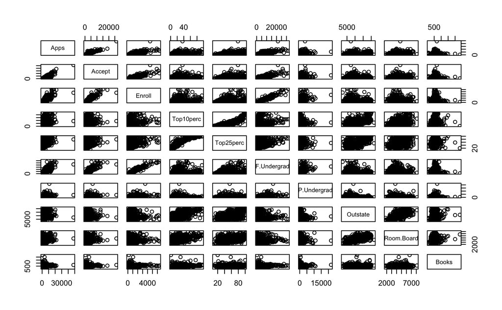

```r
# The first column is whether or not it is a private school (character) and isn't allowed by `pairs`
pairs(college[,2:11])
```

### 8c iii

> Use the `plot()` function to produce side-by-side boxplots of `Outstate` versus `Private`.

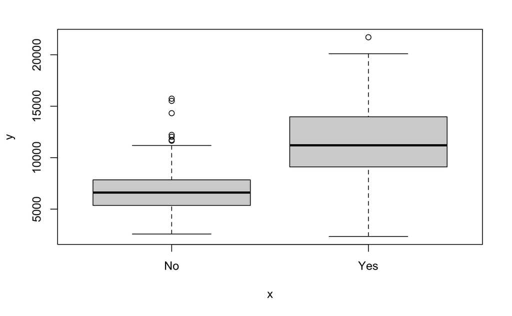

```r
college$Private <- as.factor(college$Private)
plot(college$Private, college$Outstate)
```

### 8c iv

> Create a new qualitative variable, called `Elite`, by binning the `Top10perc` variable. We are going to divide universities into two groups based on whether or not the proportion of students coming from the top $10\%$ of their high school classes exceeds $50\%$. `Elite <- rep("No", nrow(college))`

> `Elite[college$Top10perc > 50] <- "Yes"`

> `Elite <- as.factor(Elite)`

> `college <- data.frame(college, Elite)` Use the `summary()` function to see how many elite univer- sities there are. Now use the `plot()` function to produce side-by-side boxplots of `Outstate` versus `Elite`.

```r
# Here's the code they gave you, but it's super inefficient
# Elite <- rep("No", nrow(college))
# Elite[college$Top10perc > 50] <- "Yes"
# Elite <- as.factor(Elite)
# college <- data.frame(college, Elite)
college$Elite <- as.factor(ifelse(college$Top10perc > 50, "Yes", "No"))
summary(college$Elite)
```

```
 No Yes
699  78
```

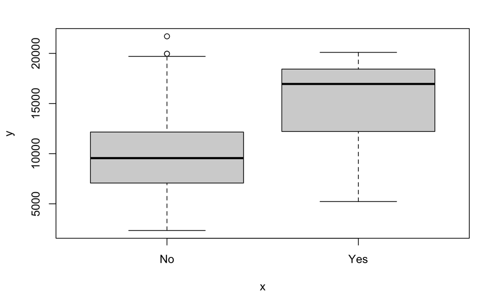

```r
plot(college$Elite, college$Outstate)
```

### 8c v

> Use the `hist()` function to produce some histograms with differing numbers of bins for a few of the quantitative vari- ables. You may find the command `par(mfrow = c(2, 2))` useful: it will divide the print window into four regions so that four plots can be made simultaneously. Modifying the arguments to this function will divide the screen in other ways.

```r
par(mfrow = c(2, 2))
hist(college$Apps, breaks = 5)
hist(college$Accept, breaks = 10)
```

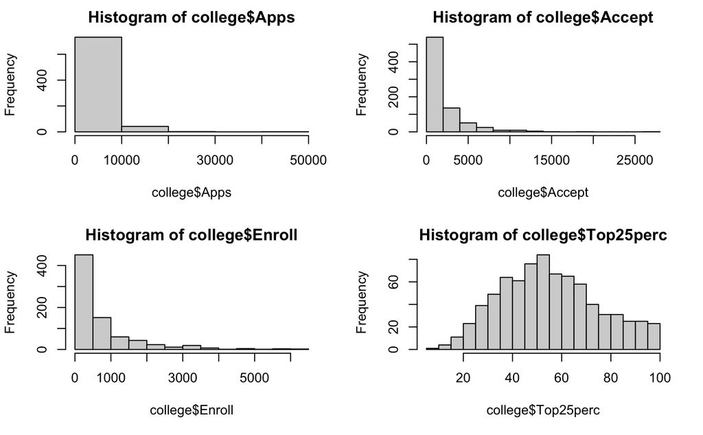

```r
hist(college$Enroll, breaks = 15)
hist(college$Top25perc, breaks = 25)
```

### 8c vi

> Continue exploring the data, and provide a brief summary of what you discover.

```r
college$AcceptRate <- college$Accept / college$Apps
acceptRate <- lm(Grad.Rate ~ AcceptRate, data = college)
acceptRate
```

```
Call:
lm(formula = Grad.Rate ~ AcceptRate, data = college)

Coefficients:
(Intercept)   AcceptRate
      90.49       -33.51
```

```r
summary(acceptRate)
```

```
Call:
lm(formula = Grad.Rate ~ AcceptRate, data = college)

Residuals:
    Min      1Q  Median      3Q     Max
-58.491 -10.806   0.968  12.496  57.411

Coefficients:
            Estimate Std. Error t value Pr(>|t|)
(Intercept)   90.493      3.059   29.58  < 2e-16 ***
AcceptRate   -33.510      4.018   -8.34 3.39e-16 ***
---
Signif. codes:  0 ‘***’ 0.001 ‘**’ 0.01 ‘*’ 0.05 ‘.’ 0.1 ‘ ’ 1

Residual standard error: 16.47 on 775 degrees of freedom
Multiple R-squared:  0.08235,   Adjusted R-squared:  0.08117
F-statistic: 69.55 on 1 and 775 DF,  p-value: 3.39e-16
```

People generally assume that schools with lower acceptance rates are more prestigious and more academically rigorous. I wanted to see if that is true. I created a metric for the acceptance rate: $\frac{\textrm{# accepted}}{\textrm{# apps}}$. I then performed a simple linear regression to see if the acceptance rate is a good predictor of the graduation rate. In theory, it is based on p-value, but not based on the R-squared.

## 9

> This exercise involves the `Auto` data set studied in the lab. Make sure that the missing values have been removed from the data.

```r
library(data.table)
library(tidyverse)
auto <- fread("Auto.csv")
# This checks for na values
sum(is.na(auto))
```

```
[1] 0
```

### 9a

> Which of the predictors are quantitative, and which are qualitative?

```r
# These are quantitative
colnames(select_if(auto, is.numeric))
```

```
[1] "mpg"          "cylinders"    "displacement" "weight"       "acceleration" "year"         "origin"
```

```r
# These are qualitative
colnames(select_if(auto, negate(is.numeric)))
```

```
[1] "horsepower" "name"
```

### 9b

> What is the range of each quantitative predictor? You can answer this using the `range()` function.

```r
sapply(select_if(auto, is.numeric), range)
```

```
      mpg cylinders displacement weight acceleration year origin
[1,]  9.0         3           68   1613          8.0   70      1
[2,] 46.6         8          455   5140         24.8   82      3
```

### 9c

> What is the mean and standard deviation of each quantitative predictor?

```r
sapply(select_if(auto, is.numeric), mean)
```

```
         mpg    cylinders displacement       weight acceleration         year       origin
   23.515869     5.458438   193.532746  2970.261965    15.555668    75.994962     1.574307
```

```r
sapply(select_if(auto, is.numeric), sd)
```

```
         mpg    cylinders displacement       weight acceleration         year       origin
   7.8258039    1.7015770  104.3795833  847.9041195    2.7499953    3.6900049    0.8025495
```

### 9d

> Now remove the 10th through 85th observations. What is the range, mean, and standard deviation of each predictor in the subset of the data that remains?

```r
smallAuto <- auto[c(1:9, 85:nrow(auto)),]
summary(select_if(smallAuto, is.numeric))
```

```
      mpg          cylinders      displacement       weight      acceleration        year           origin
 Min.   :11.00   Min.   :3.000   Min.   : 68.0   Min.   :1649   Min.   : 8.50   Min.   :70.00   Min.   :1.000
 1st Qu.:18.00   1st Qu.:4.000   1st Qu.: 98.5   1st Qu.:2211   1st Qu.:14.00   1st Qu.:75.00   1st Qu.:1.000
 Median :23.95   Median :4.000   Median :144.5   Median :2792   Median :15.55   Median :77.00   Median :1.000
 Mean   :24.45   Mean   :5.366   Mean   :186.8   Mean   :2931   Mean   :15.73   Mean   :77.14   Mean   :1.602
 3rd Qu.:30.65   3rd Qu.:6.000   3rd Qu.:250.0   3rd Qu.:3494   3rd Qu.:17.27   3rd Qu.:80.00   3rd Qu.:2.000
 Max.   :46.60   Max.   :8.000   Max.   :455.0   Max.   :4997   Max.   :24.80   Max.   :82.00   Max.   :3.000
```

### 9e

> Using the full data set, investigate the predictors graphically, using scatterplots or other tools of your choice. Create some plots highlighting the relationships among the predictors. Comment on your findings.

```r
SmartEDA::ExpReport(data = auto, op_file = "9e.html", Target = "mpg")
```

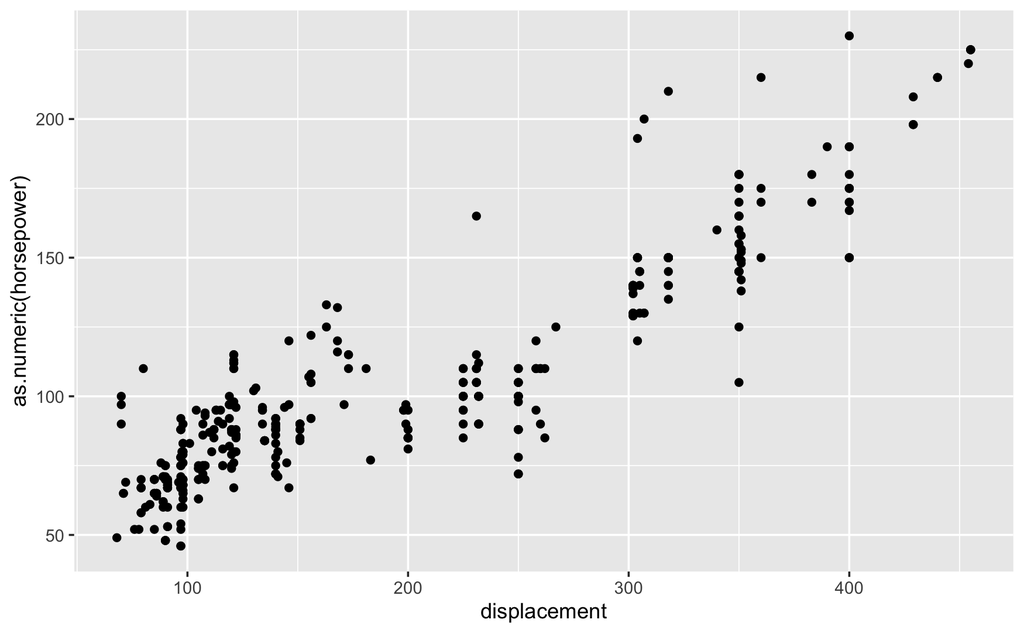

```r
auto %>%
  ggplot() +
  geom_point(aes(x = displacement, y = as.numeric(horsepower)))
```

Wow. Displacement generally correlates with horsepower. Who could have predicted this?

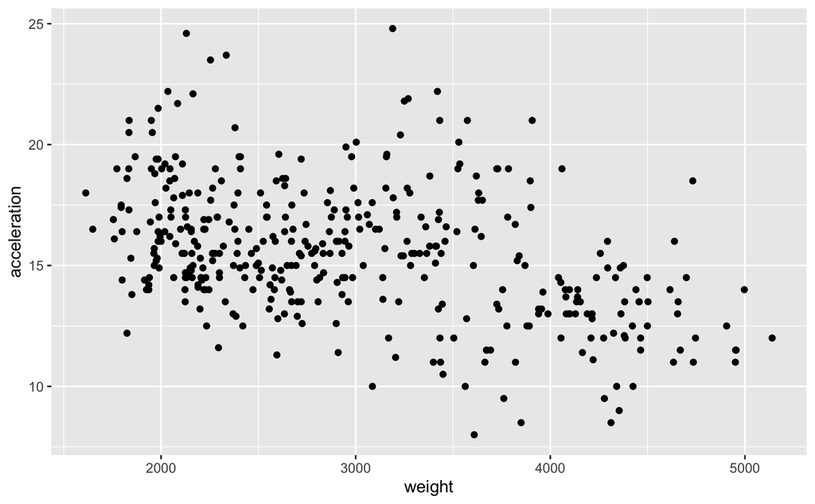

```r
auto %>%
  ggplot() +
  geom_point(aes(x = weight, y = acceleration))
```

```r
bigCarGoSlow <- lm(acceleration ~ weight + displacement, data = auto)
bigCarGoSlow
```

```
Call:
lm(formula = acceleration ~ weight + displacement, data = auto)

Coefficients:
 (Intercept)        weight  displacement
   15.002648      0.002214     -0.031115
```

```r
summary(bigCarGoSlow)
```

```
Call:
lm(formula = acceleration ~ weight + displacement, data = auto)

Residuals:
    Min      1Q  Median      3Q     Max
-5.6813 -1.5377 -0.1879  1.2041  7.9007

Coefficients:
               Estimate Std. Error t value Pr(>|t|)
(Intercept)  15.0026477  0.5959068  25.176  < 2e-16 ***
weight        0.0022135  0.0003645   6.072 2.97e-09 ***
displacement -0.0311147  0.0029612 -10.507  < 2e-16 ***
---
Signif. codes:  0 ‘***’ 0.001 ‘**’ 0.01 ‘*’ 0.05 ‘.’ 0.1 ‘ ’ 1

Residual standard error: 2.212 on 394 degrees of freedom
Multiple R-squared:  0.3563,    Adjusted R-squared:  0.3531
F-statistic: 109.1 on 2 and 394 DF,  p-value: < 2.2e-16
```

Horsepower should really be converted to numeric but I don’t care. Big car go slow is probably correct unless it’s an electric Hummer.

### 9f

> Suppose that we wish to predict gas mileage (`mpg`) on the basis of the other variables. Do your plots suggest that any of the other variables might be useful in predicting `mpg`? Justify your answer.

```r
auto$horsepower <- as.numeric(auto$horsepower)
mpg <- lm(mpg ~ cylinders + displacement + horsepower + weight + acceleration + year + origin, data = auto)
mpg
```

```
Call:
lm(formula = mpg ~ cylinders + displacement + horsepower + weight +
    acceleration + year + origin, data = auto)

Coefficients:
 (Intercept)     cylinders  displacement    horsepower        weight  acceleration          year        origin
  -17.218435     -0.493376      0.019896     -0.016951     -0.006474      0.080576      0.750773      1.426140
```

```r
summary(mpg)
```

```
Call:
lm(formula = mpg ~ cylinders + displacement + horsepower + weight +
    acceleration + year + origin, data = auto)

Residuals:
    Min      1Q  Median      3Q     Max
-9.5903 -2.1565 -0.1169  1.8690 13.0604

Coefficients:
               Estimate Std. Error t value Pr(>|t|)
(Intercept)  -17.218435   4.644294  -3.707  0.00024 ***
cylinders     -0.493376   0.323282  -1.526  0.12780
displacement   0.019896   0.007515   2.647  0.00844 **
horsepower    -0.016951   0.013787  -1.230  0.21963
weight        -0.006474   0.000652  -9.929  < 2e-16 ***
acceleration   0.080576   0.098845   0.815  0.41548
year           0.750773   0.050973  14.729  < 2e-16 ***
origin         1.426141   0.278136   5.127 4.67e-07 ***
---
Signif. codes:  0 ‘***’ 0.001 ‘**’ 0.01 ‘*’ 0.05 ‘.’ 0.1 ‘ ’ 1

Residual standard error: 3.328 on 384 degrees of freedom
  (5 observations deleted due to missingness)
Multiple R-squared:  0.8215,    Adjusted R-squared:  0.8182
F-statistic: 252.4 on 7 and 384 DF,  p-value: < 2.2e-16
```

Based on p-values, `displacement`, `weight`, `year`, and `origin` are all good predictors for `mpg`.

## 10

> This exercise involves the Boston housing data set.

### 10a

To begin, load in the `Boston` data set. The `Boston` data set is part of the `ISLR2` *library*. > > `library(ISLR2)` > > Now the data set is contained in the object Boston. > Boston > > Read about the data set: > `?Boston` > > How many rows are in this data set? How many columns? What do the rows and columns represent?

```r
library(ISLR2)
Boston
```

|  | crim | zn | indus | chas | nox | rm | age | dis | rad | tax | ptratio | lstat | medv |
| --- | --- | --- | --- | --- | --- | --- | --- | --- | --- | --- | --- | --- | --- |
| 1 | 0.00632 | 18.0 | 2.31 | 0 | 0.5380 | 6.575 | 65.2 | 4.0900 | 1 | 296 | 15.3 | 4.98 | 24.0 |
| 2 | 0.02731 | 0.0 | 7.07 | 0 | 0.4690 | 6.421 | 78.9 | 4.9671 | 2 | 242 | 17.8 | 9.14 | 21.6 |
| 3 | 0.02729 | 0.0 | 7.07 | 0 | 0.4690 | 7.185 | 61.1 | 4.9671 | 2 | 242 | 17.8 | 4.03 | 34.7 |
| 4 | 0.03237 | 0.0 | 2.18 | 0 | 0.4580 | 6.998 | 45.8 | 6.0622 | 3 | 222 | 18.7 | 2.94 | 33.4 |
| 5 | 0.06905 | 0.0 | 2.18 | 0 | 0.4580 | 7.147 | 54.2 | 6.0622 | 3 | 222 | 18.7 | 5.33 | 36.2 |
| 6 | 0.02985 | 0.0 | 2.18 | 0 | 0.4580 | 6.430 | 58.7 | 6.0622 | 3 | 222 | 18.7 | 5.21 | 28.7 |
| 7 | 0.08829 | 12.5 | 7.87 | 0 | 0.5240 | 6.012 | 66.6 | 5.5605 | 5 | 311 | 15.2 | 12.43 | 22.9 |
| 8 | 0.14455 | 12.5 | 7.87 | 0 | 0.5240 | 6.172 | 96.1 | 5.9505 | 5 | 311 | 15.2 | 19.15 | 27.1 |
| 9 | 0.21124 | 12.5 | 7.87 | 0 | 0.5240 | 5.631 | 100.0 | 6.0821 | 5 | 311 | 15.2 | 29.93 | 16.5 |
| 10 | 0.17004 | 12.5 | 7.87 | 0 | 0.5240 | 6.004 | 85.9 | 6.5921 | 5 | 311 | 15.2 | 17.10 | 18.9 |

[output cut: 496 more lines]

```r
?Boston
```

### 10b

> Make some pairwise scatterplots of the predictors (columns) in this data set. Describe your findings.

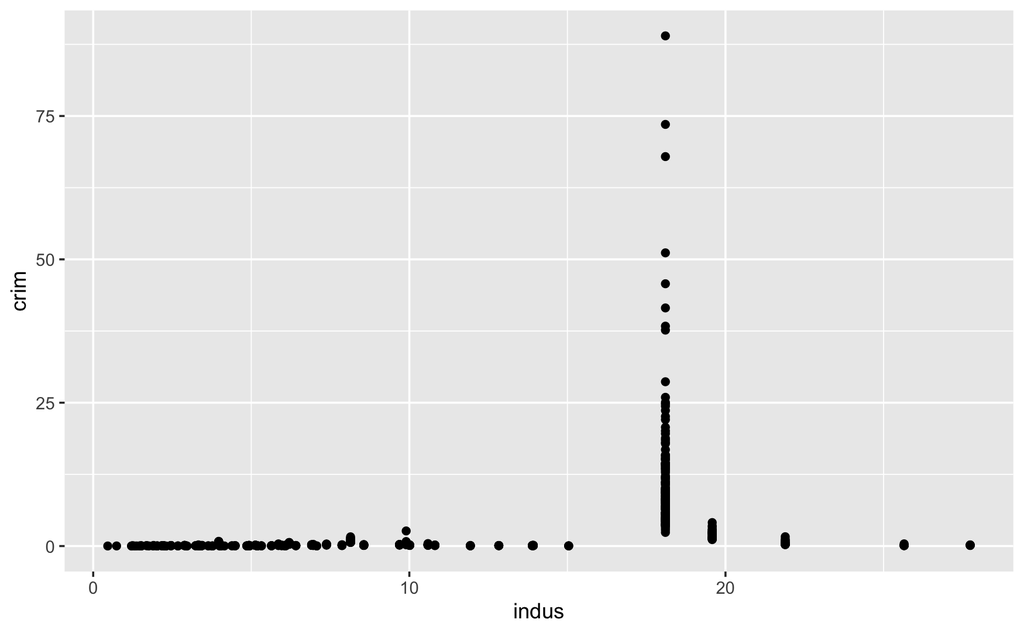

```r
# Predict crime rate based on industry
Boston %>%
  ggplot() +
  geom_point(aes(x = indus, y = crim))
```

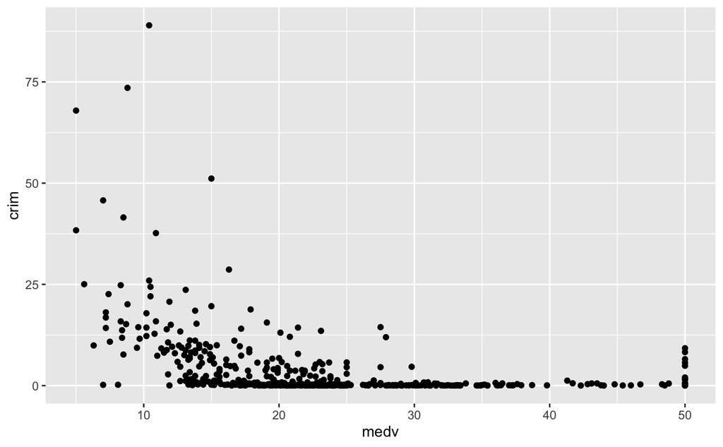

```r
# Predict crime rate based on median home value
Boston %>%
  ggplot() +
  geom_point(aes(x = medv, y = crim))
```

Crime rates are low based on my selection criteria or maybe some places just have too much crime. I just looked at the next question. I hate this.

### 10c

> Are any of the predictors associated with per capita crime rate? If so, explain the relationship.

```r
crim <- lm(crim ~ zn + indus + chas + nox + rm + age + dis + rad + tax + ptratio + lstat + medv, data = Boston)
crim
```

```
Call:
lm(formula = crim ~ zn + indus + chas + nox + rm + age + dis +
    rad + tax + ptratio + lstat + medv, data = Boston)

Coefficients:
(Intercept)           zn        indus         chas          nox           rm          age          dis
 13.7783938    0.0457100   -0.0583501   -0.8253776   -9.9575865    0.6289107   -0.0008483   -1.0122467
        rad          tax      ptratio        lstat         medv
  0.6124653   -0.0037756   -0.3040728    0.1388006   -0.2200564
```

```r
summary(crim)
```

```
Call:
lm(formula = crim ~ zn + indus + chas + nox + rm + age + dis +
    rad + tax + ptratio + lstat + medv, data = Boston)

Residuals:
   Min     1Q Median     3Q    Max
-8.534 -2.248 -0.348  1.087 73.923

Coefficients:
              Estimate Std. Error t value Pr(>|t|)
(Intercept) 13.7783938  7.0818258   1.946 0.052271 .
zn           0.0457100  0.0187903   2.433 0.015344 *
indus       -0.0583501  0.0836351  -0.698 0.485709
chas        -0.8253776  1.1833963  -0.697 0.485841
nox         -9.9575865  5.2898242  -1.882 0.060370 .
rm           0.6289107  0.6070924   1.036 0.300738
age         -0.0008483  0.0179482  -0.047 0.962323
dis         -1.0122467  0.2824676  -3.584 0.000373 ***
rad          0.6124653  0.0875358   6.997 8.59e-12 ***
tax         -0.0037756  0.0051723  -0.730 0.465757
ptratio     -0.3040728  0.1863598  -1.632 0.103393
lstat        0.1388006  0.0757213   1.833 0.067398 .
medv        -0.2200564  0.0598240  -3.678 0.000261 ***
---
Signif. codes:  0 ‘***’ 0.001 ‘**’ 0.01 ‘*’ 0.05 ‘.’ 0.1 ‘ ’ 1

Residual standard error: 6.46 on 493 degrees of freedom
Multiple R-squared:  0.4493,    Adjusted R-squared:  0.4359
F-statistic: 33.52 on 12 and 493 DF,  p-value: < 2.2e-16
```

`zn`, `dis`, `rad`, and `medv` are good predictors. `zn` and `rad` correlate with an increase in crime while `dis` and `medv` correlate with a decrease in crime.

### 10d

> Do any of the census tracts of Boston appear to have particularly high crime rates? Tax rates? Pupil-teacher ratios? Comment on the range of each predictor.

```r
# DataExplorer::create_report(data = Boston,
#                             output_file = "10d.html",
#                             report_title = "Exploratory Data Analysis Report for
#                             the Boston Dataset with a Focus on the Per Capita
#                             Crime Rate",
#                             y = "crim")
# rmarkdown::pandoc_convert("10d.html", to = "pdf", from = "html", output = "10d.pdf")
```

```r
par(mfrow = c(1, 3))
hist(Boston$crim[Boston$crim > 20], breaks = 20)
hist(Boston$tax, breaks = 20)
```

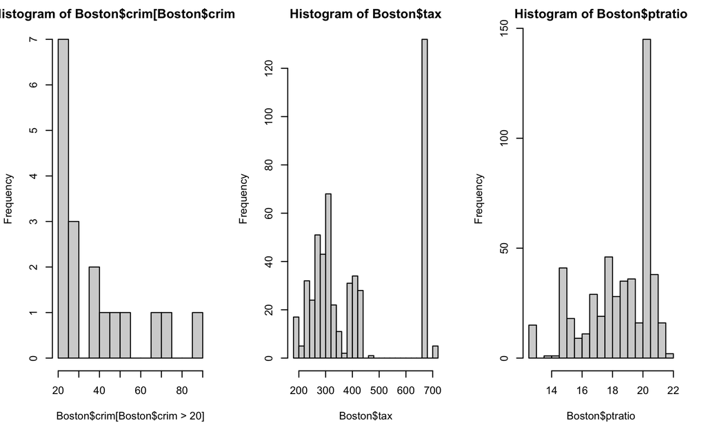

```r
hist(Boston$ptratio, breaks = 20)
```

Some places have much higher predictor values than other places. It’s probably the wealthy areas, I haven’t looked.

### 10e

> How many of the census tracts in this data set bound the Charles river?

```r
nrow(Boston[Boston$chas == 1,])
```

```
[1] 35
```

### 10f

> What is the median pupil-teacher ratio among the towns in this data set?

```r
summary(Boston$ptratio)[3]
```

```
Median
 19.05
```

### 10g

> Which census tract of Boston has lowest median value of owner-occupied homes? What are the values of the other predictors for that census tract, and how do those values compare to the overall ranges for those predictors? Comment on your findings.

```r
Boston[Boston$medv == min(Boston$medv),]
```

|  | crim | zn | indus | chas | nox | rm | age | dis | rad | tax | ptratio | lstat | medv |
| --- | --- | --- | --- | --- | --- | --- | --- | --- | --- | --- | --- | --- | --- |
| 399 | 38.3518 | 0 | 18.1 | 0 | 0.693 | 5.453 | 100 | 1.4896 | 24 | 666 | 20.2 | 30.59 | 5 |
| 406 | 67.9208 | 0 | 18.1 | 0 | 0.693 | 5.683 | 100 | 1.4254 | 24 | 666 | 20.2 | 22.98 | 5 |

`crim` and `lstat` are the only variables that are very different from each other. I’m not sure which tracts these are so I can’t comment too much. But I do like that the tax is $666$.

### 10h

> In this data set, how many of the census tracts average more than seven rooms per dwelling? More than eight rooms per dwelling? Comment on the census tracts that average more than eight rooms per dwelling.

```r
# More than 7 rooms
nrow(Boston[Boston$rm > 7,])
```

```
[1] 64
```

```r
# More than 8 rooms
nrow(Boston[Boston$rm > 8,])
```

```
[1] 13
```

```r
summary(Boston[Boston$rm <= 8,])
```

```
      crim                zn            indus            chas              nox               rm
 Min.   : 0.00632   Min.   :  0.0   Min.   : 0.46   Min.   :0.00000   Min.   :0.3850   Min.   :3.561
 1st Qu.: 0.08014   1st Qu.:  0.0   1st Qu.: 5.19   1st Qu.:0.00000   1st Qu.:0.4490   1st Qu.:5.879
 Median : 0.24522   Median :  0.0   Median : 9.69   Median :0.00000   Median :0.5380   Median :6.185
 Mean   : 3.68986   Mean   : 11.3   Mean   :11.24   Mean   :0.06694   Mean   :0.5551   Mean   :6.230
 3rd Qu.: 3.77498   3rd Qu.: 12.5   3rd Qu.:18.10   3rd Qu.:0.00000   3rd Qu.:0.6240   3rd Qu.:6.575
 Max.   :88.97620   Max.   :100.0   Max.   :27.74   Max.   :1.00000   Max.   :0.8710   Max.   :7.929
      age             dis              rad              tax           ptratio          lstat            medv
 Min.   :  2.9   Min.   : 1.130   Min.   : 1.000   Min.   :187.0   Min.   :12.60   Min.   : 1.73   Min.   : 5.00
 1st Qu.: 44.4   1st Qu.: 2.088   1st Qu.: 4.000   1st Qu.:280.0   1st Qu.:17.40   1st Qu.: 7.34   1st Qu.:16.70
 Median : 77.3   Median : 3.216   Median : 5.000   Median :334.0   Median :19.10   Median :11.65   Median :21.00
 Mean   : 68.5   Mean   : 3.805   Mean   : 9.604   Mean   :410.4   Mean   :18.51   Mean   :12.87   Mean   :21.96
 3rd Qu.: 94.3   3rd Qu.: 5.215   3rd Qu.:24.000   3rd Qu.:666.0   3rd Qu.:20.20   3rd Qu.:17.11   3rd Qu.:24.80
 Max.   :100.0   Max.   :12.127   Max.   :24.000   Max.   :711.0   Max.   :22.00   Max.   :37.97   Max.   :50.00
```

```r
summary(Boston[Boston$rm > 8,])
```

```
      crim               zn            indus             chas             nox               rm
 Min.   :0.02009   Min.   : 0.00   Min.   : 2.680   Min.   :0.0000   Min.   :0.4161   Min.   :8.034
 1st Qu.:0.33147   1st Qu.: 0.00   1st Qu.: 3.970   1st Qu.:0.0000   1st Qu.:0.5040   1st Qu.:8.247
 Median :0.52014   Median : 0.00   Median : 6.200   Median :0.0000   Median :0.5070   Median :8.297
 Mean   :0.71879   Mean   :13.62   Mean   : 7.078   Mean   :0.1538   Mean   :0.5392   Mean   :8.349
 3rd Qu.:0.57834   3rd Qu.:20.00   3rd Qu.: 6.200   3rd Qu.:0.0000   3rd Qu.:0.6050   3rd Qu.:8.398
 Max.   :3.47428   Max.   :95.00   Max.   :19.580   Max.   :1.0000   Max.   :0.7180   Max.   :8.780
      age             dis             rad              tax           ptratio          lstat           medv
 Min.   : 8.40   Min.   :1.801   Min.   : 2.000   Min.   :224.0   Min.   :13.00   Min.   :2.47   Min.   :21.9
 1st Qu.:70.40   1st Qu.:2.288   1st Qu.: 5.000   1st Qu.:264.0   1st Qu.:14.70   1st Qu.:3.32   1st Qu.:41.7
 Median :78.30   Median :2.894   Median : 7.000   Median :307.0   Median :17.40   Median :4.14   Median :48.3
 Mean   :71.54   Mean   :3.430   Mean   : 7.462   Mean   :325.1   Mean   :16.36   Mean   :4.31   Mean   :44.2
 3rd Qu.:86.50   3rd Qu.:3.652   3rd Qu.: 8.000   3rd Qu.:307.0   3rd Qu.:17.40   3rd Qu.:5.12   3rd Qu.:50.0
 Max.   :93.90   Max.   :8.907   Max.   :24.000   Max.   :666.0   Max.   :20.20   Max.   :7.44   Max.   :50.0
```

I’m just going to focus on the age bit because Boston is an historic city and area. I’m not surprised that larger homes are generally older than those that are not as large. This is probably due to old mansions which are abundant in the area. Also, median value is way higher for larger homes which is not at all surprising. I wish I knew what the tracts actually were so I could comment on that specific area rather than just the data.